# Class_4_Kickstarter-Preprocessing&PCA

**Kickstarter** is a global crowdfunding platform. Kickstarter has reportedly received more than 1.9 billion dollors in pledges from 9.4 million backers to fund 257,000 creative projects, such as films, music, stage shows, comics, journalism, video games, technology and food-related projects.

A huge variety of factors contribute to the success or failure of a project — in general, and also on Kickstarter. Some of these are able to be quantified or categorised, which allows for the construction of a model to attempt to predict whether a project will succeed or not. The aim of this project is to construct such a model and also to analyse Kickstarter project data more generally, in order to help potential project creators assess whether or not Kickstarter is a good funding option for them, and what their chances of success are.

```python
## load required libraries
import matplotlib.pyplot as plt
import pandas as pd
import numpy as np
import warnings
warnings.simplefilter("ignore")

projects = pd.read_csv("./ks-projects-201801.csv", parse_dates = ["launched", "deadline"])

projects.shape
```

```
(378661, 15)
```

```python
projects.head()
```

|  | ID | name | category | main_category | currency | deadline | goal | launched | pledged | state | backers | country | usd_pledged | usd_pledged_real | usd_goal_real |
| --- | --- | --- | --- | --- | --- | --- | --- | --- | --- | --- | --- | --- | --- | --- | --- |
| 0 | 1000002330 | The Songs of Adelaide & Abullah | Poetry | Publishing | GBP | 2015-10-09 | 1000.0 | 2015-08-11 12:12:28 | 0.0 | failed | 0 | GB | 0.0 | 0.0 | 1533.95 |
| 1 | 1000003930 | Greeting From Earth: ZGAC Arts Capsule For ET | Narrative Film | Film & Video | USD | 2017-11-01 | 30000.0 | 2017-09-02 04:43:57 | 2421.0 | failed | 15 | US | 100.0 | 2421.0 | 30000.00 |
| 2 | 1000004038 | Where is Hank? | Narrative Film | Film & Video | USD | 2013-02-26 | 45000.0 | 2013-01-12 00:20:50 | 220.0 | failed | 3 | US | 220.0 | 220.0 | 45000.00 |
| 3 | 1000007540 | ToshiCapital Rekordz Needs Help to Complete Album | Music | Music | USD | 2012-04-16 | 5000.0 | 2012-03-17 03:24:11 | 1.0 | failed | 1 | US | 1.0 | 1.0 | 5000.00 |
| 4 | 1000011046 | Community Film Project: The Art of Neighborhoo... | Film & Video | Film & Video | USD | 2015-08-29 | 19500.0 | 2015-07-04 08:35:03 | 1283.0 | canceled | 14 | US | 1283.0 | 1283.0 | 19500.00 |

```python
projects.describe()
```

|  | ID | goal | pledged | backers | usd_pledged | usd_pledged_real | usd_goal_real |
| --- | --- | --- | --- | --- | --- | --- | --- |
| count | 3.786610e+05 | 3.786610e+05 | 3.786610e+05 | 378661.000000 | 3.748640e+05 | 3.786610e+05 | 3.786610e+05 |
| mean | 1.074731e+09 | 4.908079e+04 | 9.682979e+03 | 105.617476 | 7.036729e+03 | 9.058924e+03 | 4.545440e+04 |
| std | 6.190862e+08 | 1.183391e+06 | 9.563601e+04 | 907.185035 | 7.863975e+04 | 9.097334e+04 | 1.152950e+06 |
| min | 5.971000e+03 | 1.000000e-02 | 0.000000e+00 | 0.000000 | 0.000000e+00 | 0.000000e+00 | 1.000000e-02 |
| 25% | 5.382635e+08 | 2.000000e+03 | 3.000000e+01 | 2.000000 | 1.698000e+01 | 3.100000e+01 | 2.000000e+03 |
| 50% | 1.075276e+09 | 5.200000e+03 | 6.200000e+02 | 12.000000 | 3.947200e+02 | 6.243300e+02 | 5.500000e+03 |
| 75% | 1.610149e+09 | 1.600000e+04 | 4.076000e+03 | 56.000000 | 3.034090e+03 | 4.050000e+03 | 1.550000e+04 |
| max | 2.147476e+09 | 1.000000e+08 | 2.033899e+07 | 219382.000000 | 2.033899e+07 | 2.033899e+07 | 1.663614e+08 |

```python
projects.info()
```

```
<class 'pandas.core.frame.DataFrame'>
RangeIndex: 378661 entries, 0 to 378660
Data columns (total 15 columns):
 #   Column            Non-Null Count   Dtype
---  ------            --------------   -----
 0   ID                378661 non-null  int64
 1   name              378657 non-null  object
 2   category          378661 non-null  object
 3   main_category     378661 non-null  object
 4   currency          378661 non-null  object
 5   deadline          378661 non-null  datetime64[ns]
 6   goal              378661 non-null  float64
 7   launched          378661 non-null  datetime64[ns]
 8   pledged           378661 non-null  float64
 9   state             378661 non-null  object
 10  backers           378661 non-null  int64
 11  country           378661 non-null  object
 12  usd_pledged       374864 non-null  float64
 13  usd_pledged_real  378661 non-null  float64
 14  usd_goal_real     378661 non-null  float64
dtypes: datetime64[ns](2), float64(5), int64(2), object(6)
memory usage: 43.3+ MB
```

### Data Preprocessing

- Handle Missing Values

```python
missing = projects.isnull().sum()
print(missing)
```

```
ID                     0
name                   4
category               0
main_category          0
currency               0
deadline               0
goal                   0
launched               0
pledged                0
state                  0
backers                0
country                0
usd_pledged         3797
usd_pledged_real       0
usd_goal_real          0
dtype: int64
```

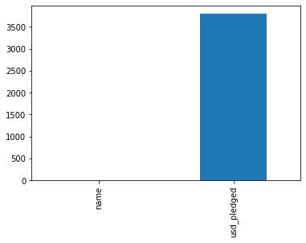

```python
missing = missing[missing>0]
missing.sort_values(inplace=True)
missing.plot.bar()
```

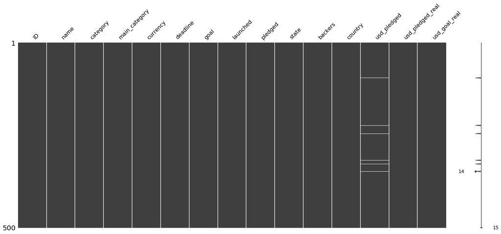

```python
import missingno as msno

msno.matrix(projects.sample(500))
```

因为只有一个变量有较多缺失值，所以在这里的效果不太明显 ，拿其他数据看一下效果

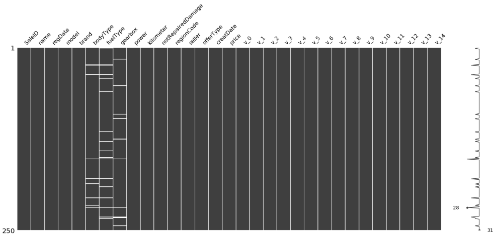

```python
## remove all the rows that contain a missing value
projects = projects.dropna()
print ("Total Projects: ", projects.shape[0])
```

```
Total Projects:  374860
```

- Remove Duplicated Rows

```python
projects.drop_duplicates(subset = ["ID"], inplace = True)
print ("Total Projects: ", projects.shape[0])
```

```
Total Projects:  374860
```

- Transform Column "state" into Binary (only "successful" & "failed")

```
['failed' 'canceled' 'successful' 'live' 'suspended']
state
failed        197611
successful    133851
canceled       38757
live            2798
suspended       1843
Name: ID, dtype: int64
```

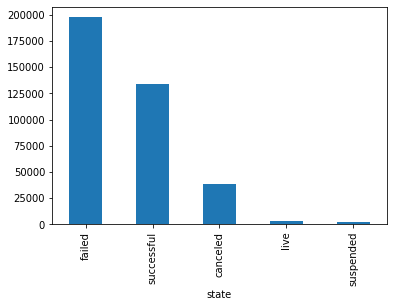

```python
## state
print(projects["state"].unique())
projects_state_count = projects.groupby("state").count()["ID"].sort_values(ascending = False)
print(projects_state_count)
projects_state_count.plot.bar()
plt.show()
projects = projects[projects["state"].isin(["failed", "successful"])]
```

- Drop Unwanted Columns

```python
projects = projects.drop(["backers", "ID", "currency", "country", "pledged", "usd_pledged", "usd_pledged_real", "usd_goal_real"], axis = 1)
projects.head()
```

|  | name | category | main_category | deadline | goal | launched | state |
| --- | --- | --- | --- | --- | --- | --- | --- |
| 0 | The Songs of Adelaide & Abullah | Poetry | Publishing | 2015-10-09 | 1000.0 | 2015-08-11 12:12:28 | failed |
| 1 | Greeting From Earth: ZGAC Arts Capsule For ET | Narrative Film | Film & Video | 2017-11-01 | 30000.0 | 2017-09-02 04:43:57 | failed |
| 2 | Where is Hank? | Narrative Film | Film & Video | 2013-02-26 | 45000.0 | 2013-01-12 00:20:50 | failed |
| 3 | ToshiCapital Rekordz Needs Help to Complete Album | Music | Music | 2012-04-16 | 5000.0 | 2012-03-17 03:24:11 | failed |
| 5 | Monarch Espresso Bar | Restaurants | Food | 2016-04-01 | 50000.0 | 2016-02-26 13:38:27 | successful |

- Data Transformation

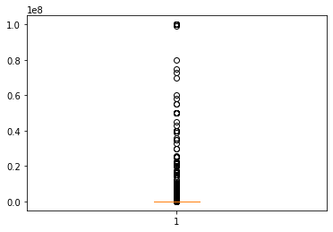

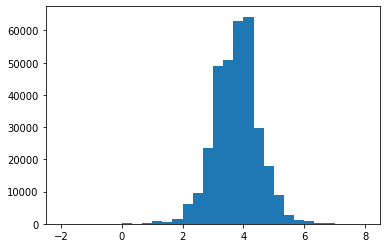

```python
## goal
plt.boxplot(projects["goal"])
plt.show()
## log transformation
projects["goal"] = np.log10(projects.goal.values)
plt.hist(projects["goal"], bins = 30)
plt.show()
```

### Feature Engineering

1. **Project Name Features:**

We suggested that how the project name is written may affect the success of the project. So we create some features related to the project name:

- Number of Words Used
- Number of Characters Used
1. **Project Launched Date Features:**

Also, we suggested that the project first launch can affect its success. So we create some features related to the project launched date:

- Launched Day, Week, Month,Year
- Total Duration of the Project
- Was project launched on weekday or weekend
1. **Project Category Features**:

The category / main-category of the project may also affect its success.

```python
## feature engineering
projects["num_words"] = projects["name"].apply(lambda x: len(x.split()))
projects["num_chars"] = projects["name"].apply(lambda x: len(x.replace(" ","")))
projects["launched_day"] = projects["launched"].dt.weekday
projects["launched_week"] = projects["launched"].dt.week
projects["launched_month"] = projects["launched"].dt.month
projects["launched_year"] = projects["launched"].dt.year
projects["duration"] = projects["deadline"] - projects["launched"]
projects["duration"] = projects["duration"].apply(lambda x: int(str(x).split()[0]))
projects["is_weekend"] = projects["launched_day"].apply(lambda x: 1 if x > 4 else 0)
projects["state"] = projects["state"].apply(lambda x: 1 if x == "successful" else 0)
projects = pd.concat([projects, pd.get_dummies(projects["category"]), pd.get_dummies(projects["main_category"]), pd.get_dummies(projects["launched_day"]), pd.get_dummies(projects["launched_week"]), pd.get_dummies(projects["launched_month"]), pd.get_dummies(projects["launched_year"])], axis = 1)
projects = projects.drop(["category", "main_category", "launched", "deadline", "launched_day", "launched_week", "launched_month", "launched_year"], axis = 1)
projects.head()
```

|  | name | goal | state | num_words | num_chars | duration | is_weekend | 3D Printing | Academic | Accessories | ... | 12 | 2009 | 2010 | 2011 | 2012 | 2013 | 2014 | 2015 | 2016 | 2017 |
| --- | --- | --- | --- | --- | --- | --- | --- | --- | --- | --- | --- | --- | --- | --- | --- | --- | --- | --- | --- | --- | --- |
| 0 | The Songs of Adelaide & Abullah | 3.000000 | 0 | 6 | 26 | 58 | 0 | 0 | 0 | 0 | ... | 0 | 0 | 0 | 0 | 0 | 0 | 0 | 1 | 0 | 0 |
| 1 | Greeting From Earth: ZGAC Arts Capsule For ET | 4.477121 | 0 | 8 | 38 | 59 | 1 | 0 | 0 | 0 | ... | 0 | 0 | 0 | 0 | 0 | 0 | 0 | 0 | 0 | 1 |
| 2 | Where is Hank? | 4.653213 | 0 | 3 | 12 | 44 | 1 | 0 | 0 | 0 | ... | 0 | 0 | 0 | 0 | 0 | 1 | 0 | 0 | 0 | 0 |
| 3 | ToshiCapital Rekordz Needs Help to Complete Album | 3.698970 | 0 | 7 | 43 | 29 | 1 | 0 | 0 | 0 | ... | 0 | 0 | 0 | 0 | 1 | 0 | 0 | 0 | 0 | 0 |
| 5 | Monarch Espresso Bar | 4.698970 | 1 | 3 | 18 | 34 | 0 | 0 | 0 | 0 | ... | 0 | 0 | 0 | 0 | 0 | 0 | 0 | 0 | 1 | 0 |

5 rows × 262 columns

### Principal Component Analysis

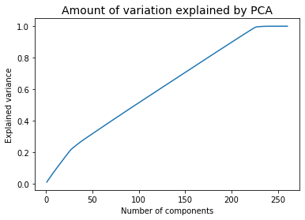

```
Number of components explaining 80% of variance: 175
Number of components explaining 90% of variance: 201
Number of components explaining 99% of variance: 225
```

```python
from sklearn.preprocessing import StandardScaler
from sklearn.decomposition import PCA

projects_X = projects.drop(["name", "state"], axis = 1)
scaler = StandardScaler()
projects_X = scaler.fit_transform(projects_X)

# Fitting PCA
pca = PCA()
pca.fit_transform(projects_X)
explained_var = np.cumsum(pca.explained_variance_ratio_)

# Plotting the amount of variation explained by PCA with different numbers of components
plt.plot(list(range(1, len(explained_var)+1)), explained_var)
plt.title('Amount of variation explained by PCA', fontsize = 14)
plt.xlabel('Number of components')
plt.ylabel('Explained variance')
plt.show()

print("Number of components explaining 80% of variance:", np.where(explained_var > 0.8)[0][0] + 1)
print("Number of components explaining 90% of variance:", np.where(explained_var > 0.9)[0][0] + 1)
print("Number of components explaining 99% of variance:", np.where(explained_var > 0.99)[0][0] + 1)
```

```python
## 225
pca = PCA(n_components = 225)
projects_X_225 = pca.fit_transform(projects_X)
print(projects_X_225.shape)
```

```
(331462, 225)
```

```python
components = pca.components_
print(components.shape)
```

```
(225, 260)
```

- Origin website: https://towardsdatascience.com/using-machine-learning-to-predict-kickstarter-success-e371ab56a743
- First edited by Jiawei Chen